# Homework4

Lia

2023-10-25

## Challenge 1

**Description:** Write a simple R function, Z.prop.test(), that can perform one- or two-sample Z-tests for proportion data.

Load the packages first.

```r
library(curl)
```

```r
library(ggplot2)
library(dplyr)
```

Write the function then.

```r
Z.prop.test <- function(p1, n1, p0, alternative="two.sided", p2=NULL, n2=NULL, conf.level=0.95){
  result_list <- NULL

  z_value=NULL
  p_value=NULL
  conf_interval=NULL

  if (is.null(p2)==FALSE & is.null(n2)==FALSE) {
    if((((n1*p1<5) | (n1*(1-p1)<5)) | (n2*p2<5) | (n2*(1-p2)<5))){
    print("Warning! The approximation can only be true when n is fairly large and p is not close to 0 or 1.")
    }
    phat <- (p1*n1+p2*n2)/(n1+n2)
    num <- 1/n1+1/n2
    z_value=(p2-p1)/(sqrt(phat*(1-phat)*(1/n1+1/n2)))
    norma <- 1-((1-conf.level)/2)
    lower <- phat-qnorm(norma)*sqrt(phat*(1-phat)/num)
    upper <- phat+qnorm(norma)*sqrt(phat*(1-phat)/num)
    conf_interval=c(lower, upper)
    if(alternative=="less"){
      p_value=pnorm(z_value, lower.tail=TRUE)
    }
    if(alternative=="greater"){
      p_value=pnorm(z_value, lower.tail=FALSE)
    }
    if(alternative=="two.sided"){
      p_value=2*pnorm(z_value, lower.tail=FALSE)
    }
  }
 if (is.null(p2)==TRUE & is.null(n2)==TRUE) {
   if((n1*p1<5) | (n1*(1-p1)<5)){
    print("Warning! The approximation can only be true when n is fairly large and p is not close to 0 or 1.")
   }
   phat <- mean(p1)
   z_value=(phat-p0)/(sqrt(p0*(1-p0)/n1))
   norma <- 1-((1-conf.level)/2)
   lower <- phat-qnorm(norma)*sqrt(phat*(1-phat)/n1)
   upper <- phat+qnorm(norma)*sqrt(phat*(1-phat)/n1)
   conf_interval=c(lower, upper)
   if(alternative=="less"){
      p_value=pnorm(z_value, lower.tail=TRUE)
   }
   if(alternative=="greater"){
      p_value=pnorm(z_value, lower.tail=FALSE)
   }
   if(alternative=="two.sided"){
      p_value=2*pnorm(z_value, lower.tail=FALSE)
   }
 }
  result_list=list(z_value, p_value, conf_interval)
  names(result_list) <- c("Z-value", "P-value", "Confidence interval")
  return(result_list)
}
```

I guess we can test this function now.

1. Warning?

```r
Z.prop.test(p1=0.5, n1=1, p0=0.6)
```

```
## [1] "Warning! The approximation can only be true when n is fairly large and p is not close to 0 or 1."
```

```
## $`Z-value`
## [1] -0.2041241
##
## $`P-value`
## [1] 1.161744
##
## $`Confidence interval`
## [1] -0.479982  1.479982
```

```r
Z.prop.test(p1=0.5, n1=1, p0=0.6, p2=0.3, n2=1)
```

```
## [1] "Warning! The approximation can only be true when n is fairly large and p is not close to 0 or 1."
```

```
## $`Z-value`
## [1] -0.2886751
##
## $`P-value`
## [1] 1.22717
##
## $`Confidence interval`
## [1] -0.2789514  1.0789514
```

Warning message produced normally.

2. Alternative option?

```r
Z.prop.test(p1=0.7, n1=30, p0=0.5, alternative="less")
```

```
## $`Z-value`
## [1] 2.19089
##
## $`P-value`
## [1] 0.9857701
##
## $`Confidence interval`
## [1] 0.5360176 0.8639824
```

```r
Z.prop.test(p1=0.7, n1=40, p0=0.5, alternative="greater", p2=0.4, n2=30)
```

```
## $`Z-value`
## [1] -2.50998
##
## $`P-value`
## [1] 0.9939631
##
## $`Confidence interval`
## [1] -3.444466  4.587323
```

```r
Z.prop.test(p1=0.7, n1=40, p0=0.5, alternative="less", p2=0.4, n2=30)
```

```
## $`Z-value`
## [1] -2.50998
##
## $`P-value`
## [1] 0.006036899
##
## $`Confidence interval`
## [1] -3.444466  4.587323
```

Alternative option works (no error message at least haha im so screwed)

3. Confidence level?

```r
Z.prop.test(p1=0.7, n1=40, p0=0.8)
```

```
## $`Z-value`
## [1] -1.581139
##
## $`P-value`
## [1] 1.886154
##
## $`Confidence interval`
## [1] 0.5579871 0.8420129
```

```r
Z.prop.test(p1=0.7, n1=40, p0=0.8, conf.level=0.6)
```

```
## $`Z-value`
## [1] -1.581139
##
## $`P-value`
## [1] 1.886154
##
## $`Confidence interval`
## [1] 0.6390187 0.7609813
```

Nice the confidence interval result changes.

## Challenge 2

The dataset from Kamilar and Cooper has in it a large number of variables related to life history and body size. For this exercise, the end aim is to fit a simple linear regression model to predict longevity (MaxLongevity_m) measured in months from species’ brain size (Brain_Size_Species_Mean) measured in grams. Do the following for both longevity~brain size and log(longevity)~log(brain size)

Read the data.

```r
f <- curl("https://raw.githubusercontent.com/fuzzyatelin/fuzzyatelin.github.io/master/AN588_Fall21/KamilarAndCooperData.csv")
KC <- read.csv(f, header=TRUE, sep=",", stringsAsFactors=FALSE) %>% filter(!is.na(MaxLongevity_m)) %>% filter(!is.na(Brain_Size_Species_Mean))
```

Model creation.

```r
lmod <- lm(MaxLongevity_m~Brain_Size_Species_Mean, data=KC)
summary(lmod)
```

```
##
## Call:
## lm(formula = MaxLongevity_m ~ Brain_Size_Species_Mean, data = KC)
##
## Residuals:
##     Min      1Q  Median      3Q     Max
## -198.27  -61.92  -17.78   56.16  331.36
##
## Coefficients:
##                         Estimate Std. Error t value Pr(>|t|)
## (Intercept)             248.9523    11.1111   22.41   <2e-16 ***
## Brain_Size_Species_Mean   1.2180     0.1101   11.06   <2e-16 ***
## ---
## Signif. codes:  0 '***' 0.001 '**' 0.01 '*' 0.05 '.' 0.1 ' ' 1
##
## Residual standard error: 90.91 on 126 degrees of freedom
## Multiple R-squared:  0.4928, Adjusted R-squared:  0.4887
## F-statistic: 122.4 on 1 and 126 DF,  p-value: < 2.2e-16
```

Plot creation.

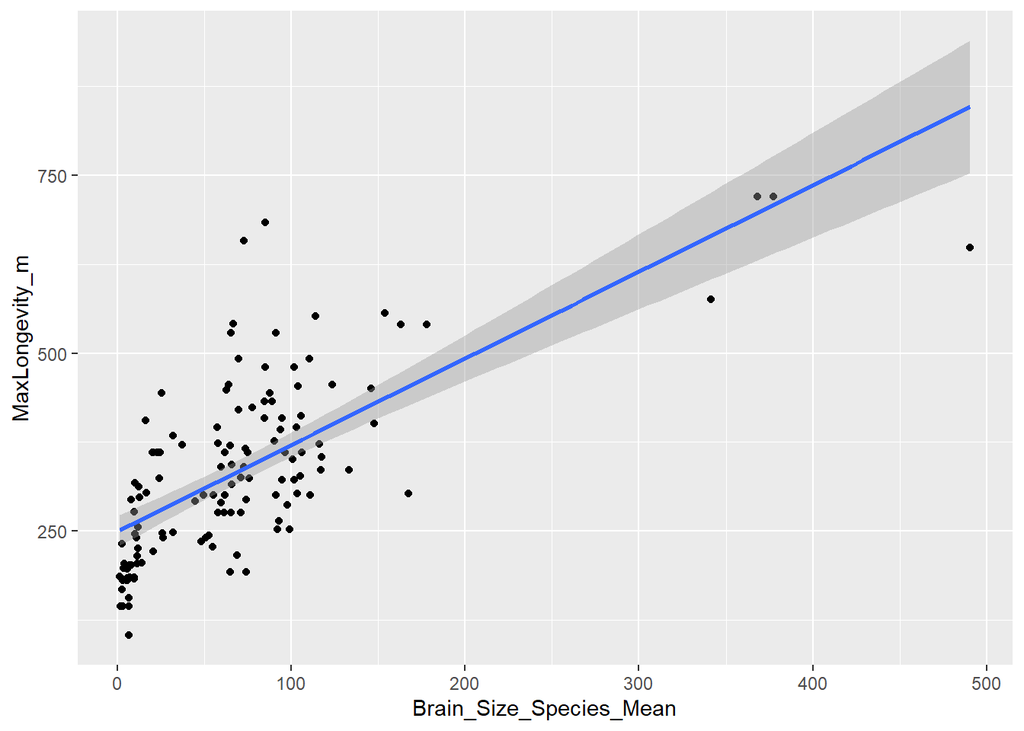

```r
g <- ggplot(data=KC, aes(x=Brain_Size_Species_Mean, y=MaxLongevity_m))
g <- g+geom_point()
g <- g+geom_smooth(method="lm", formula=y~x)
g
```

Repeat the process with log.

```r
logmod <- lm((log(MaxLongevity_m))~(log(Brain_Size_Species_Mean)), data=KC)
summary(logmod)
```

```
##
## Call:
## lm(formula = (log(MaxLongevity_m)) ~ (log(Brain_Size_Species_Mean)),
##     data = KC)
##
## Residuals:
##     Min      1Q  Median      3Q     Max
## -0.6955 -0.1750 -0.0097  0.1788  0.6084
##
## Coefficients:
##                              Estimate Std. Error t value Pr(>|t|)
## (Intercept)                   4.87895    0.06907   70.63   <2e-16 ***
## log(Brain_Size_Species_Mean)  0.23415    0.01781   13.15   <2e-16 ***
## ---
## Signif. codes:  0 '***' 0.001 '**' 0.01 '*' 0.05 '.' 0.1 ' ' 1
##
## Residual standard error: 0.2485 on 126 degrees of freedom
## Multiple R-squared:  0.5784, Adjusted R-squared:  0.5751
## F-statistic: 172.9 on 1 and 126 DF,  p-value: < 2.2e-16
```

Plot creation.

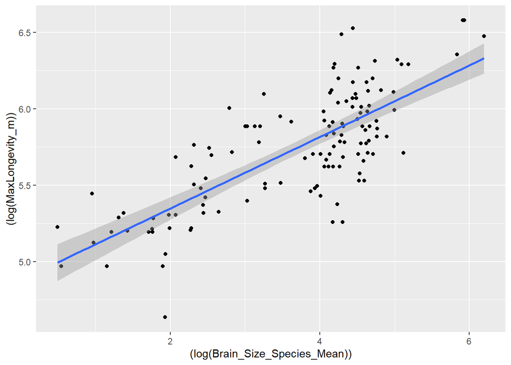

```r
g <- ggplot(data=KC, aes(x=(log(Brain_Size_Species_Mean)), y=(log(MaxLongevity_m))))
g <- g+geom_point()
g <- g+geom_smooth(method="lm", formula=y~x)
g
```

Prediction part!

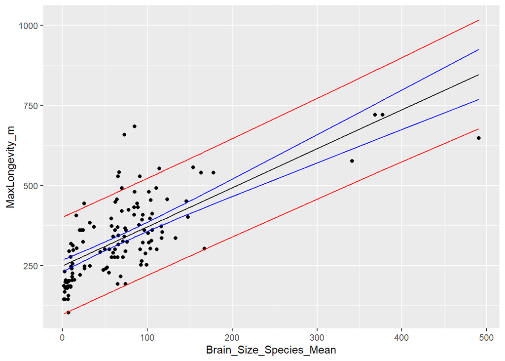

```r
hat90 <- predict(lmod, newdata=data.frame(Brain_Size_Species_Mean=KC$Brain_Size_Species_Mean))
conf90 <- predict(lmod, newdata=data.frame(Brain_Size_Species_Mean=KC$Brain_Size_Species_Mean), interval="confidence", level=0.9)
pred90 <- predict(lmod, newdata=data.frame(Brain_Size_Species_Mean=KC$Brain_Size_Species_Mean), interval="prediction", level=0.9)
df <- data.frame(cbind(KC$Brain_Size_Species_Mean, KC$MaxLongevity_m, hat90))
names(df) <- c("Brain_Size_Species_Mean", "MaxLongevity_m", "hat")
df <- cbind(df, conf90, pred90)
names(df) <- c("Brain_Size_Species_Mean", "MaxLongevity_m", "hat", "conf90fit", "conf90lwr", "conf90upr", "pred90fit", "pred90lwr", "pred90upr")
g <- ggplot(data=df, aes(x=Brain_Size_Species_Mean, y=MaxLongevity_m))
g <- g+geom_point()
g <- g+geom_line(aes(x=Brain_Size_Species_Mean, y=conf90fit), colour="black")+geom_line(aes(x=Brain_Size_Species_Mean, y=conf90lwr), colour="blue")+geom_line(aes(x=Brain_Size_Species_Mean, y=conf90upr), colour="blue")
g <- g+geom_line(data=df, aes(x=Brain_Size_Species_Mean, y=pred90lwr), colour="red")+geom_line(data=df, aes(x=Brain_Size_Species_Mean, y=pred90upr), colour="red")
g
```

This is really killing me but let’s do it for log.

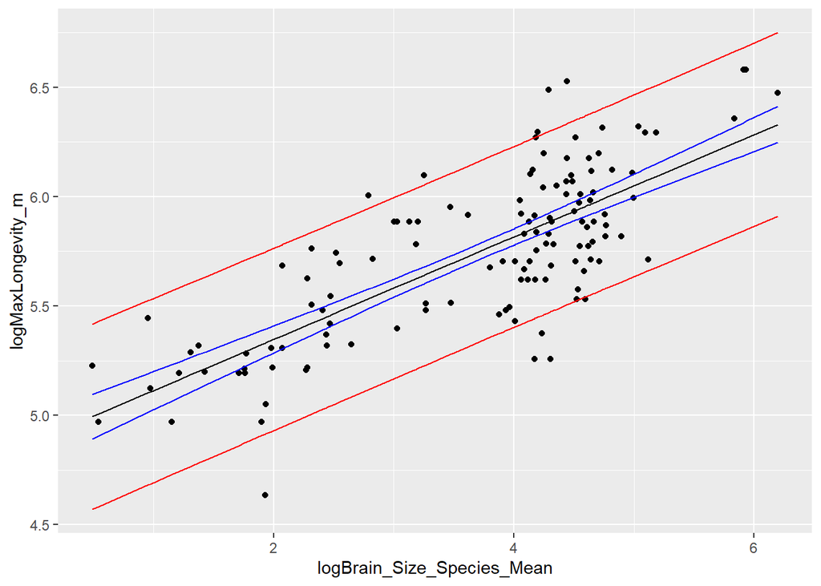

```r
loghat90 <- predict(logmod, newdata=data.frame(Brain_Size_Species_Mean=KC$Brain_Size_Species_Mean))
logconf90 <- predict(logmod, newdata=data.frame(Brain_Size_Species_Mean=KC$Brain_Size_Species_Mean), interval="confidence", level=0.9)
logpred90 <- predict(logmod, newdata=data.frame(Brain_Size_Species_Mean=KC$Brain_Size_Species_Mean), interval="prediction", level=0.9)
df2 <- data.frame(cbind(log(KC$Brain_Size_Species_Mean), log(KC$MaxLongevity_m), loghat90))
names(df) <- c("logBrain_Size_Species_Mean", "logMaxLongevity_m", "loghat")
df2 <- cbind(df2, logconf90, logpred90)
names(df2) <- c("logBrain_Size_Species_Mean", "logMaxLongevity_m", "loghat", "logconf90fit", "logconf90lwr", "logconf90upr", "logpred90fit", "logpred90lwr", "logpred90upr")
g <- ggplot(data=df2, aes(x=logBrain_Size_Species_Mean, y=logMaxLongevity_m))
g <- g+geom_point()
g <- g+geom_line(aes(x=logBrain_Size_Species_Mean, y=logconf90fit), colour="black")+geom_line(aes(x=logBrain_Size_Species_Mean, y=logconf90lwr), colour="blue")+geom_line(aes(x=logBrain_Size_Species_Mean, y=logconf90upr), colour="blue")
g <- g+geom_line(data=df2, aes(x=logBrain_Size_Species_Mean, y=logpred90lwr), colour="red")+geom_line(data=df2, aes(x=logBrain_Size_Species_Mean, y=logpred90upr), colour="red")
g
```

Finally! Let’s do the prediction.

```r
pest <- predict(lmod, newdata=data.frame(Brain_Size_Species_Mean=c(800), interval="prediction", level=0.9))
pest
```

```
##        1
## 1223.345
```

```r
logpest <- predict(logmod, newdata=data.frame(Brain_Size_Species_Mean=c(800)), interval="prediction", level=0.9)
logpest
```

```
##       fit      lwr      upr
## 1 6.44415 6.021424 6.866876
```

Oh my God it’s finally done (I hope so)

Good night sleep sleep